# FIT3152 Assignment 2

Xinyu Ma

30/05/2020

## 0. Elementary work

```r
rm(list=ls())
options(digits=4)

## load packages
 # install.packages('mlr3')
 # install.packages('tree')
 # install.packages('e1071')
 # install.packages('adabag')
 # install.packages('rpart')
 # install.packages('randomForest')
 # install.packages('ROCR')
 # install.packages('neuralnet')

library('mlr')
library('tree')
library('e1071')
library('adabag')
library('rpart')
library('randomForest')
library('ROCR')
library('C50')
library('neuralnet')


WAUS <- read.csv('WAUS2020.csv')

L <- as.data.frame(c(1:49))

set.seed(28652703)

L <- L[sample(nrow(L), 10, replace = FALSE), ]

WAUS <- WAUS[(WAUS$Location %in% L), ]

WAUS <- WAUS[sample(nrow(WAUS), 2000, replace = FALSE), ]
```

## 1. Explore the data

```r
# the proportion of rainy days to fine days
table(WAUS$RainTomorrow)[2]/table(WAUS$RainTomorrow)[1]
```

```
##    Yes
## 0.2909
```

```r
# structure of data
str(WAUS)
```

```
## 'data.frame':    2000 obs. of  25 variables:
##  $ Day          : int  27 31 21 24 1 31 10 23 13 2 ...
##  $ Month        : int  7 8 8 11 1 10 8 7 3 7 ...
##  $ Year         : int  2014 2019 2012 2017 2014 2018 2013 2014 2018 2010 ...
##  $ Location     : int  7 13 40 8 7 8 13 8 40 3 ...
##  $ MinTemp      : num  -0.1 5.7 18.1 17.4 13 15.6 5.7 9.4 20.4 0.2 ...
##  $ MaxTemp      : num  14.2 19.1 24.4 28.8 28.1 27 15.7 22.8 31.8 10.9 ...
##  $ Rainfall     : num  0.2 0 0 1.2 0.2 NA 4.4 2.4 0 0.2 ...
##  $ Evaporation  : num  NA NA 3 8 7 6.8 0.8 3.6 8.4 NA ...
##  $ Sunshine     : num  NA NA 1.3 12.4 NA 9.9 8.1 9.8 NA NA ...
##  $ WindGustDir  : Factor w/ 16 levels "E","ENE","ESE",..: 4 4 3 1 7 6 15 1 5 3 ...
##  $ WindGustSpeed: int  31 59 31 33 59 24 37 20 39 19 ...
##  $ WindDir9am   : Factor w/ 16 levels "E","ENE","ESE",..: NA 4 10 3 11 6 7 13 10 9 ...
##  $ WindDir3pm   : Factor w/ 16 levels "E","ENE","ESE",..: 4 7 3 1 4 5 14 5 2 11 ...
##  $ WindSpeed9am : int  0 20 15 7 20 6 9 7 19 2 ...
##  $ WindSpeed3pm : int  17 22 22 19 11 7 17 6 28 7 ...
##  $ Humidity9am  : int  99 59 74 61 43 59 94 76 54 99 ...
##  $ Humidity3pm  : int  78 50 67 50 31 54 68 54 55 70 ...
##  $ Pressure9am  : num  1027 1020 1020 1017 1010 ...
##  $ Pressure3pm  : num  1022 1016 1016 1014 1006 ...
##  $ Cloud9am     : int  8 NA 8 3 3 6 NA 1 NA 8 ...
##  $ Cloud3pm     : int  7 NA 6 1 4 1 NA 3 NA 4 ...
##  $ Temp9am      : num  3.8 12.3 20.5 24.9 19.6 24.2 8.4 14.5 27.6 3.2 ...
##  $ Temp3pm      : num  13.2 17.8 23.9 27.1 26.6 26.8 15.1 19.8 29.7 10.2 ...
##  $ RainToday    : Factor w/ 2 levels "No","Yes": 1 1 1 2 1 NA 2 2 1 1 ...
##  $ RainTomorrow : Factor w/ 2 levels "No","Yes": 1 2 1 1 2 1 1 1 1 1 ...
```

The dataset contains factor and numerical variables. Also, there are missing values in the dataset. First, we omit the whole row which contains *NA*.

```r
WAUS <- WAUS[!apply(WAUS, 1, anyNA), ]
dim(WAUS)
```

```
## [1] 859  25
```

```r
WAUS <- WAUS[, -c(1:3)]
```

The dataset shrinks from 2000 rows to 859 rows. We deleted the *Day*, *Month*, and *Year* variables because these variables cannot help to predict *RainTomorrow*. Then we explore the variables.

```r
attach(WAUS)

## for numerical variables
num <- c('MinTemp', 'MaxTemp', 'Rainfall', 'Evaporation', 'Sunshine', 'WindGustSpeed',
         'WindSpeed9am', 'WindSpeed3pm', 'Humidity9am', 'Humidity3pm', 'Pressure9am',
         'Pressure3pm', 'Cloud9am', 'Cloud3pm', 'Temp9am', 'Temp3pm')

fact <- c('WindGustDir', 'WindDir9am', 'WindDir3pm', 'RainToday')



# summary statistics
apply(WAUS[, num], 2, function(x) {
  c(mean=mean(x), median=median(x), sd=sd(x), min=min(x), IQR=IQR(x), max=max(x))
})
```

```
##        MinTemp MaxTemp Rainfall Evaporation Sunshine WindGustSpeed WindSpeed9am
## mean    13.144  23.167    1.796       5.126    7.752         40.07       14.036
## median  12.800  22.900    0.000       4.600    8.800         37.00       13.000
## sd       5.747   6.067    5.401       3.024    3.641         14.56        8.524
## min     -1.400   8.600    0.000       0.000    0.000         11.00        2.000
## IQR      8.800   9.050    0.800       4.500    5.400         18.00       12.000
## max     28.200  41.000   62.800      15.200   13.700        113.00       52.000
##        WindSpeed3pm Humidity9am Humidity3pm Pressure9am Pressure3pm Cloud9am
## mean         19.061       65.27       51.92    1017.714    1015.306    4.168
## median       17.000       65.00       51.00    1018.300    1015.700    5.000
## sd            9.635       15.33       15.96       7.378       7.287    2.757
## min           2.000       18.00        9.00     987.400     986.500    0.000
## IQR          13.000       21.00       20.00       9.150       8.600    6.000
## max          57.000       99.00       98.00    1040.000    1038.500    8.000
##        Cloud3pm Temp9am Temp3pm
## mean      4.208  17.699  21.535
## median    5.000  17.500  21.500
## sd        2.643   6.147   5.885
## min       0.000   2.500   5.800
## IQR       6.000   9.400   8.350
## max       8.000  33.900  37.200
```

The *Rainfall* may contain outliers, we will use boxplot to verify it.

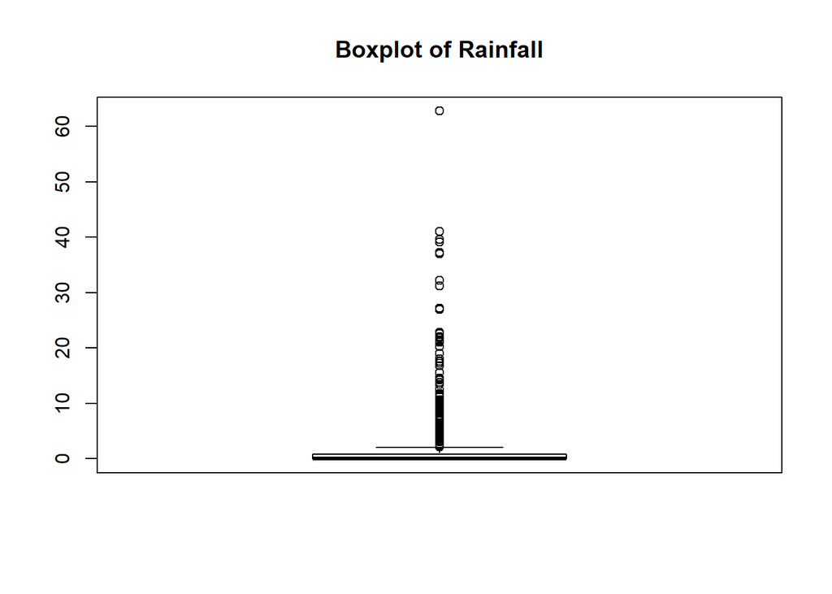

```r
boxplot(Rainfall, main='Boxplot of Rainfall')
```

Looking at the categorical variables.

```r
## for factor variables

# Raintoday and Raintomorrow again
table(today=RainToday, tomorrow=RainTomorrow)/length(RainToday)
```

```
##      tomorrow
## today      No     Yes
##   No  0.64377 0.13620
##   Yes 0.13853 0.08149
```

```r
# Wind Gust direction: the proportion of rainy days to fine days
WGD <- table(WindGustDir, RainTomorrow)[, 2]/table(WindGustDir, RainTomorrow)[, 1]

# Wind direction at 9am
WD9 <- table(WindDir9am, RainTomorrow)[, 2]/table(WindDir9am, RainTomorrow)[, 1]

# Wind direction at 3am
WD3 <- table(WindDir3pm, RainTomorrow)[, 2]/table(WindDir3pm, RainTomorrow)[, 1]

data.frame(WGD, WD9, WD3)
```

```
##        WGD    WD9     WD3
## E   0.1000 0.1818 0.26531
## ENE 0.1061 0.1923 0.12162
## ESE 0.4000 0.1667 0.25490
## N   0.4857 0.4667 0.46429
## NE  0.3043 0.5714 0.22034
## NNE 0.2692 0.7895 0.42105
## NNW 0.3462 0.1406 0.76923
## NW  0.4474 0.3725 0.84000
## S   0.4211 0.3548 0.31818
## SE  0.4194 0.3214 0.23077
## SSE 0.2333 0.2647 0.33333
## SSW 0.2131 0.2558 0.29268
## SW  0.1765 0.1806 0.08065
## W   0.2131 0.3409 0.24528
## WNW 0.3939 0.1892 0.35484
## WSW 0.3429 0.2333 0.23684
```

```r
apply(data.frame(WGD, WD9, WD3), 2, mean)
```

```
##    WGD    WD9    WD3
## 0.3045 0.3139 0.3406
```

```r
apply(data.frame(WGD, WD9, WD3), 2, sd)
```

```
##    WGD    WD9    WD3
## 0.1214 0.1735 0.2054
```

The proportion of rainy days to fine days of *WindDir* differs in different directions. Maybe it is an important variable.

## 2. Pre-process

Removing the missing values by omitting the whole row, which showed in part 1.

Then process the *Rainfall* outliers.

```r
toprainfall <- quantile(Rainfall, 0.75) + 3*IQR(Rainfall)

WAUS$Rainfall <- ifelse(WAUS$Rainfall >= toprainfall, toprainfall, WAUS$Rainfall)
```

Categorical variables need to be transformed into indicator variables.

```r
Locat <- createDummyFeatures(data.frame(Locat = as.factor(Location)))

WGD_dum <- createDummyFeatures(data.frame(WGD = as.factor(WindGustDir)))

WD9am_dum <- createDummyFeatures(data.frame(WD9am = as.factor(WindDir9am)))

WD3pm_dum <- createDummyFeatures(data.frame(WD3pm = as.factor(WindDir3pm)))

RT_dum <- createDummyFeatures(data.frame(RT = as.factor(RainToday)))
```

We scale all the numerical variables and bind the new dataset that suitable for the model fitting.

```r
WAUS <- cbind(scale(WAUS[, num]), cbind(Locat,
                                 WGD_dum,
                                 WD9am_dum,
                                 WD3pm_dum,
                                 RT_dum), RainTomorrow=as.factor(RainTomorrow))

dim(WAUS)
```

```
## [1] 859  74
```

## 3. Divide train and test set

```r
set.seed(28652703)
train.row <- sample(1:nrow(WAUS), 0.7*nrow(WAUS))

train <- WAUS[train.row, ]

test.x <- WAUS[-train.row, -ncol(WAUS)]
test.y <- WAUS[-train.row, ncol(WAUS)]
```

## 4. Fitting classification models

```r
WAUS.tree <- tree(RainTomorrow ~ ., data = train)

WAUS.NB <- naiveBayes(RainTomorrow ~ ., data = train)

WAUS.Bagging <- bagging(RainTomorrow ~ ., data = train)

WAUS.Boosting <- boosting(RainTomorrow ~ ., data = train)

WAUS.RF <- randomForest(RainTomorrow ~ ., data = train)
```

## 5. Classification comparison

Identify the test data and create confusion matrix.

```r
# Decision Tree
tree.pred <- predict(WAUS.tree, test.x, type='class')
tree.cm <- table(observed=test.y, predicted=tree.pred)
tree.ac <- (tree.cm[1, 1] + tree.cm[2, 2])/sum(tree.cm)
# confusion matrix
tree.cm
```

```
##         predicted
## observed  No Yes
##      No  168  30
##      Yes  36  24
```

```r
# Naive Bayes
NB.pred <- predict(WAUS.NB, test.x)
NB.cm <- table(observed=test.y, predicted=NB.pred)
NB.ac <- (NB.cm[1, 1] + NB.cm[2, 2])/sum(NB.cm)
# confusion matrix
NB.cm
```

```
##         predicted
## observed  No Yes
##      No  136  62
##      Yes  24  36
```

```r
# Bagging
Bagging.pred <- predict(WAUS.Bagging, test.x)
Bagging.cm <- table(observed=test.y, predicted=Bagging.pred$class)
Bagging.ac <- (Bagging.cm[1, 1] + Bagging.cm[2, 2])/sum(Bagging.cm)
# confusion matrix
Bagging.cm
```

```
##         predicted
## observed  No Yes
##      No  192   6
##      Yes  34  26
```

```r
# Boosting
Boosting.pred <- predict(WAUS.Boosting, test.x)
Boosting.cm <- table(observed=test.y, predicted=Boosting.pred$class)
Boosting.ac <- (Boosting.cm[1, 1] + Boosting.cm[2, 2])/sum(Boosting.cm)
# confusion matrix
Boosting.cm
```

```
##         predicted
## observed  No Yes
##      No  183  15
##      Yes  34  26
```

```r
# Random Forest
RF.pred <- predict(WAUS.RF, test.x)
RF.cm <- table(observed=test.y, predicted=RF.pred)
RF.ac <- (RF.cm[1, 1] + RF.cm[2, 2])/sum(RF.cm)
# confusion matrix
RF.cm
```

```
##         predicted
## observed  No Yes
##      No  192   6
##      Yes  36  24
```

Report the accuracy of each model.

```r
ac <- data.frame(ModelName = c('tree', 'NaiveBayes', 'Bagging',
                               'Boosting', 'randomForest'),
                 Accuracy = c(tree.ac, NB.ac, Bagging.ac,
                              Boosting.ac, RF.ac))
ac
```

```
##      ModelName Accuracy
## 1         tree   0.7442
## 2   NaiveBayes   0.6667
## 3      Bagging   0.8450
## 4     Boosting   0.8101
## 5 randomForest   0.8372
```

## 6. Confidence, ROC and AUC

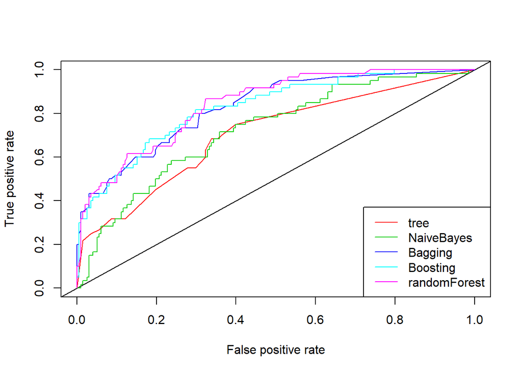

```r
# confidence of predicting
tree.pred.conf <- predict(WAUS.tree, test.x, type='vector')
treepred <- ROCR::prediction(tree.pred.conf[, 2], test.y)
treeperf <- ROCR::performance(treepred, 'tpr', 'fpr')
tree.auc <- ROCR::performance(treepred, 'auc')@y.values[[1]]


NB.pred.conf <- predict(WAUS.NB, test.x, type='raw')
NBpred <- ROCR::prediction(NB.pred.conf[, 2], test.y)
NBperf <- ROCR::performance(NBpred, 'tpr', 'fpr')
NB.auc <- ROCR::performance(NBpred, 'auc')@y.values[[1]]


Baggingpred <- ROCR::prediction(Bagging.pred$prob[, 2], test.y)
Baggingperf <- ROCR::performance(Baggingpred, 'tpr', 'fpr')
Bagging.auc <- ROCR::performance(Baggingpred, 'auc')@y.values[[1]]


Boostingpred <- ROCR::prediction(Boosting.pred$prob[, 2], test.y)
Boostingperf <- ROCR::performance(Boostingpred, 'tpr', 'fpr')
Boosting.auc <- ROCR::performance(Boostingpred, 'auc')@y.values[[1]]


RF.pred.conf <- predict(WAUS.RF, test.x, type='prob')
RFpred <- ROCR::prediction(RF.pred.conf[, 2], test.y)
RFperf <- ROCR::performance(RFpred, 'tpr', 'fpr')
RF.auc <- ROCR::performance(RFpred, 'auc')@y.values[[1]]


# ROC plot
plot(treeperf, col=2)
abline(0, 1)
plot(NBperf, col=3, add=TRUE)
plot(Baggingperf, col=4, add=TRUE)
plot(Boostingperf, col=5, add=TRUE)
plot(RFperf, col=6, add=TRUE)
legend('bottomright', legend=c('tree', 'NaiveBayes',
                               'Bagging', 'Boosting', 'randomForest'),
       col=c(2:6), lty=1)
```

```r
# AUC
auc <- data.frame(ModelName = c('tree', 'NaiveBayes', 'Bagging',
                               'Boosting', 'randomForest'),
                  Auc = c(tree.auc, NB.auc, Bagging.auc,
                          Boosting.auc, RF.auc))
auc
```

```
##      ModelName    Auc
## 1         tree 0.7056
## 2   NaiveBayes 0.7235
## 3      Bagging 0.8295
## 4     Boosting 0.8275
## 5 randomForest 0.8433
```

## 7. Single ‘best’ classifier

```r
merge(ac, auc)
```

```
##      ModelName Accuracy    Auc
## 1      Bagging   0.8450 0.8295
## 2     Boosting   0.8101 0.8275
## 3   NaiveBayes   0.6667 0.7235
## 4 randomForest   0.8372 0.8433
## 5         tree   0.7442 0.7056
```

From the accuracy and AUC table above, we can see *randomForest* seems to be the ‘best’ classifier. Then *Boosting* or *Bagging* classification.

## 8. Important variables

```r
# Attribute importance
cat("\n#Decision Tree Attribute Importance\n")
```

```
##
## #Decision Tree Attribute Importance
```

```r
print(summary(WAUS.tree))
```

```
##
## Classification tree:
## tree(formula = RainTomorrow ~ ., data = train)
## Variables actually used in tree construction:
##  [1] "Sunshine"      "Humidity3pm"   "Humidity9am"   "WGD.NW"
##  [5] "Rainfall"      "WGD.ESE"       "WindGustSpeed" "Temp9am"
##  [9] "MaxTemp"       "Temp3pm"       "Cloud3pm"      "WindSpeed9am"
## [13] "Cloud9am"      "Evaporation"   "Pressure9am"   "WD3pm.NNW"
## [17] "WD3pm.NW"      "WD3pm.E"       "Locat.8"
## Number of terminal nodes:  29
## Residual mean deviance:  0.386 = 221 / 572
## Misclassification error rate: 0.101 = 61 / 601
```

```r
tree.im <- as.character(summary(WAUS.tree)[['used']])

cat("\n#Bagging Attribute Importance\n")
```

```
##
## #Bagging Attribute Importance
```

```r
print(WAUS.Bagging$importance)
```

```
##      Cloud3pm      Cloud9am   Evaporation   Humidity3pm   Humidity9am
##       1.52053       0.85677       3.29661      26.30190       4.62948
##      Locat.16      Locat.19      Locat.32      Locat.36      Locat.39
##       0.36773       1.45628       0.38232       0.00000       0.02646
##      Locat.40       Locat.8       MaxTemp       MinTemp   Pressure3pm
##       0.12669       0.48125       0.82643       1.37017       4.50320
##   Pressure9am      Rainfall         RT.No        RT.Yes      Sunshine
##       4.00949       3.09100       0.00000       0.00000      30.34759
##       Temp3pm       Temp9am       WD3pm.E     WD3pm.ENE     WD3pm.ESE
##       0.95019       1.42721       0.04221       0.00000       0.20290
##       WD3pm.N      WD3pm.NE     WD3pm.NNE     WD3pm.NNW      WD3pm.NW
##       0.04438       0.00000       0.00000       0.26457       0.34879
##       WD3pm.S      WD3pm.SE     WD3pm.SSE     WD3pm.SSW      WD3pm.SW
##       0.00000       0.04835       0.07221       0.10977       0.17303
##       WD3pm.W     WD3pm.WNW     WD3pm.WSW       WD9am.E     WD9am.ENE
##       0.05996       0.00000       0.00000       0.06193       0.00000
##     WD9am.ESE       WD9am.N      WD9am.NE     WD9am.NNE     WD9am.NNW
##       0.00000       0.22117       0.15797       0.24355       0.12117
##      WD9am.NW       WD9am.S      WD9am.SE     WD9am.SSE     WD9am.SSW
##       0.05003       0.03129       0.00000       0.00000       0.00000
##      WD9am.SW       WD9am.W     WD9am.WNW     WD9am.WSW         WGD.E
##       0.11077       0.13011       0.00000       0.02026       0.00000
##       WGD.ENE       WGD.ESE         WGD.N        WGD.NE       WGD.NNE
##       0.00000       0.88475       0.07201       0.10070       0.00000
##       WGD.NNW        WGD.NW         WGD.S        WGD.SE       WGD.SSE
##       0.45106       1.16815       0.12429       0.00000       0.09359
##       WGD.SSW        WGD.SW         WGD.W       WGD.WNW       WGD.WSW
##       0.21780       0.00000       0.00000       0.05355       0.00000
## WindGustSpeed  WindSpeed3pm  WindSpeed9am
##       3.83901       1.67701       2.83236
```

```r
Bagging.im <- sort(WAUS.Bagging$importance[WAUS.Bagging$importance != 0], decreasing = T)

cat("\n#Boosting Attribute Importance\n")
```

```
##
## #Boosting Attribute Importance
```

```r
print(WAUS.Boosting$importance)
```

```
##      Cloud3pm      Cloud9am   Evaporation   Humidity3pm   Humidity9am
##       2.86661       3.52305       6.61609       7.20760       4.94249
##      Locat.16      Locat.19      Locat.32      Locat.36      Locat.39
##       0.62787       0.97533       0.65461       0.18064       0.15243
##      Locat.40       Locat.8       MaxTemp       MinTemp   Pressure3pm
##       0.29405       0.88229       5.13464       5.78041       6.34405
##   Pressure9am      Rainfall         RT.No        RT.Yes      Sunshine
##       6.84276       3.10576       0.00000       0.00000       8.22516
##       Temp3pm       Temp9am       WD3pm.E     WD3pm.ENE     WD3pm.ESE
##       4.18291       3.00281       0.32588       0.08646       0.28769
##       WD3pm.N      WD3pm.NE     WD3pm.NNE     WD3pm.NNW      WD3pm.NW
##       0.14231       0.22307       0.11595       0.73421       0.85509
##       WD3pm.S      WD3pm.SE     WD3pm.SSE     WD3pm.SSW      WD3pm.SW
##       0.27745       0.10053       0.09200       0.28601       0.89265
##       WD3pm.W     WD3pm.WNW     WD3pm.WSW       WD9am.E     WD9am.ENE
##       0.06468       0.09709       0.10660       0.11774       0.10411
##     WD9am.ESE       WD9am.N      WD9am.NE     WD9am.NNE     WD9am.NNW
##       0.20715       0.18163       0.50169       0.09184       0.99780
##      WD9am.NW       WD9am.S      WD9am.SE     WD9am.SSE     WD9am.SSW
##       0.41698       0.11103       0.44950       0.07623       0.11283
##      WD9am.SW       WD9am.W     WD9am.WNW     WD9am.WSW         WGD.E
##       0.27681       0.38782       0.18978       0.23005       0.42736
##       WGD.ENE       WGD.ESE         WGD.N        WGD.NE       WGD.NNE
##       0.36011       0.64869       0.14566       0.12820       0.18926
##       WGD.NNW        WGD.NW         WGD.S        WGD.SE       WGD.SSE
##       0.41510       0.25008       0.36102       0.43887       0.23884
##       WGD.SSW        WGD.SW         WGD.W       WGD.WNW       WGD.WSW
##       0.98552       0.11892       0.22029       0.08750       0.00000
## WindGustSpeed  WindSpeed3pm  WindSpeed9am
##       6.20964       4.32618       3.76653
```

```r
Boosting.im <- sort(WAUS.Boosting$importance[WAUS.Boosting$importance != 0], decreasing = T)

cat("\n#Random Forest Attribute Importance\n")
```

```
##
## #Random Forest Attribute Importance
```

```r
print(WAUS.RF$importance)
```

```
##               MeanDecreaseGini
## MinTemp                 6.9571
## MaxTemp                 7.6852
## Rainfall                5.4883
## Evaporation             7.1685
## Sunshine               19.5874
## WindGustSpeed           8.5425
## WindSpeed9am            5.7325
## WindSpeed3pm            6.2883
## Humidity9am            11.5768
## Humidity3pm            22.0948
## Pressure9am             9.4299
## Pressure3pm            10.2544
## Cloud9am                8.1360
## Cloud3pm               11.1470
## Temp9am                 6.8878
## Temp3pm                 7.6036
## Locat.8                 1.0236
## Locat.16                0.9948
## Locat.19                1.3822
## Locat.32                1.3833
## Locat.36                0.4160
## Locat.39                0.8119
## Locat.40                0.4481
## WGD.E                   0.5646
## WGD.ENE                 0.4101
## WGD.ESE                 1.2844
## WGD.N                   0.6549
## WGD.NE                  0.3963
## WGD.NNE                 0.4199
## WGD.NNW                 1.0529
## WGD.NW                  1.2049
## WGD.S                   0.6720
## WGD.SE                  0.8381
## WGD.SSE                 0.5858
## WGD.SSW                 0.7788
## WGD.SW                  0.6484
## WGD.W                   0.5784
## WGD.WNW                 0.6102
## WGD.WSW                 0.4097
```

[output cut: 19 more lines]

```
## WD3pm.N                 0.4324
## WD3pm.NE                0.4335
## WD3pm.NNE               0.4263
## WD3pm.NNW               1.5221
## WD3pm.NW                1.7918
## WD3pm.S                 0.5702
## WD3pm.SE                0.5645
## WD3pm.SSE               0.5579
## WD3pm.SSW               0.4915
## WD3pm.SW                0.7228
## WD3pm.W                 0.5706
## WD3pm.WNW               0.7000
## WD3pm.WSW               0.3664
## RT.No                   1.9751
## RT.Yes                  1.9519
```

```r
RF.im <- sort(WAUS.RF$importance[WAUS.RF$importance != 0, ], decreasing = T)


im.list <- list(tree=tree.im, Bagging=Bagging.im, Boosting=Boosting.im,
                RF=RF.im)
im.list
```

```
## $tree
##  [1] "Sunshine"      "Humidity3pm"   "Humidity9am"   "WGD.NW"
##  [5] "Rainfall"      "WGD.ESE"       "WindGustSpeed" "Temp9am"
##  [9] "MaxTemp"       "Temp3pm"       "Cloud3pm"      "WindSpeed9am"
## [13] "Cloud9am"      "Evaporation"   "Pressure9am"   "WD3pm.NNW"
## [17] "WD3pm.NW"      "WD3pm.E"       "Locat.8"
##
## $Bagging
##      Sunshine   Humidity3pm   Humidity9am   Pressure3pm   Pressure9am
##      30.34759      26.30190       4.62948       4.50320       4.00949
## WindGustSpeed   Evaporation      Rainfall  WindSpeed9am  WindSpeed3pm
##       3.83901       3.29661       3.09100       2.83236       1.67701
##      Cloud3pm      Locat.19       Temp9am       MinTemp        WGD.NW
##       1.52053       1.45628       1.42721       1.37017       1.16815
##       Temp3pm       WGD.ESE      Cloud9am       MaxTemp       Locat.8
##       0.95019       0.88475       0.85677       0.82643       0.48125
##       WGD.NNW      Locat.32      Locat.16      WD3pm.NW     WD3pm.NNW
##       0.45106       0.38232       0.36773       0.34879       0.26457
##     WD9am.NNE       WD9am.N       WGD.SSW     WD3pm.ESE      WD3pm.SW
##       0.24355       0.22117       0.21780       0.20290       0.17303
##      WD9am.NE       WD9am.W      Locat.40         WGD.S     WD9am.NNW
##       0.15797       0.13011       0.12669       0.12429       0.12117
##      WD9am.SW     WD3pm.SSW        WGD.NE       WGD.SSE     WD3pm.SSE
##       0.11077       0.10977       0.10070       0.09359       0.07221
##         WGD.N       WD9am.E       WD3pm.W       WGD.WNW      WD9am.NW
##       0.07201       0.06193       0.05996       0.05355       0.05003
##      WD3pm.SE       WD3pm.N       WD3pm.E       WD9am.S      Locat.39
##       0.04835       0.04438       0.04221       0.03129       0.02646
##     WD9am.WSW
##       0.02026
##
## $Boosting
##      Sunshine   Humidity3pm   Pressure9am   Evaporation   Pressure3pm
##       8.22516       7.20760       6.84276       6.61609       6.34405
## WindGustSpeed       MinTemp       MaxTemp   Humidity9am  WindSpeed3pm
##       6.20964       5.78041       5.13464       4.94249       4.32618
##       Temp3pm  WindSpeed9am      Cloud9am      Rainfall       Temp9am
##       4.18291       3.76653       3.52305       3.10576       3.00281
##      Cloud3pm     WD9am.NNW       WGD.SSW      Locat.19      WD3pm.SW
##       2.86661       0.99780       0.98552       0.97533       0.89265
```

[output cut: 37 more lines]

```
##        0.7788        0.7748        0.7228        0.7000        0.6977
##     WD9am.WSW       WD9am.W         WGD.S         WGD.N        WGD.SW
##        0.6854        0.6841        0.6720        0.6549        0.6484
##     WD3pm.ESE       WD9am.S       WGD.WNW       WGD.SSE         WGD.W
##        0.6215        0.6128        0.6102        0.5858        0.5784
##       WD3pm.W       WD3pm.S         WGD.E      WD3pm.SE      WD9am.SE
##        0.5706        0.5702        0.5646        0.5645        0.5586
##     WD3pm.SSE     WD9am.SSE     WD9am.ESE     WD3pm.SSW     WD3pm.ENE
##        0.5579        0.5178        0.5143        0.4915        0.4538
##       WD9am.E      Locat.40      WD3pm.NE       WD3pm.N     WD3pm.NNE
##        0.4498        0.4481        0.4335        0.4324        0.4263
##       WGD.NNE      Locat.36       WGD.ENE       WGD.WSW        WGD.NE
##        0.4199        0.4160        0.4101        0.4097        0.3963
##     WD3pm.WSW     WD9am.WNW     WD9am.ENE
##        0.3664        0.3191        0.2413
```

Important variables are *Sunshine*, *Humidity*, *Pressure*, etc. Because these variables bring higher contribution to model accuracy and information gains.

*RainToday*, *Location* and *Wind Direction* seem to be insignificant.

## 9. Improved tree model

```r
# Tree model improved process
train_im <- train
tree_adj_fun <- function(im) {
  train_im <- train[, im]
  WAUS.tree <- tree(RainTomorrow ~ ., data = train_im)

  tree.pred <- predict(WAUS.tree, test.x, type='class')
  tree.cm <- table(observed=test.y, predicted=tree.pred)
  tree.ac <- (tree.cm[1, 1] + tree.cm[2, 2])/sum(tree.cm)

  tree.pred.conf <- predict(WAUS.tree, test.x, type='vector')
  treepred <- ROCR::prediction(tree.pred.conf[, 2], test.y)
  treeperf <- ROCR::performance(treepred, 'tpr', 'fpr')
  tree.auc <- ROCR::performance(treepred, 'auc')@y.values[[1]]

  ret1 <- c(tree.ac, tree.auc)

  # prune tree
  testtree <- cv.tree(WAUS.tree, FUN=prune.misclass)
  size <- testtree$size[which.min(testtree$dev)]

  prune.tree <- prune.misclass(WAUS.tree, best=size)
  prune.tree.pred <- predict(prune.tree, test.x, type='class')

  prune.tree.cm <- table(observed=test.y, predicted=prune.tree.pred)
  prune.tree.ac <- (prune.tree.cm[1, 1] + prune.tree.cm[2, 2])/sum(prune.tree.cm)
  prune.tree.ac

  prune.tree.pred.conf <- predict(prune.tree, test.x, type='vector')
  prune.treepred <- ROCR::prediction(prune.tree.pred.conf[, 2], test.y)
  prune.treeperf <- ROCR::performance(prune.treepred, 'tpr', 'fpr')
  prune.tree.auc <- ROCR::performance(prune.treepred, 'auc')@y.values[[1]]
  prune.tree.auc

  ret2 <- c(prune.tree.ac, prune.tree.auc)

  ret <- rbind(ret1, ret2)
  colnames(ret) <- c('Accuracy', 'AUC')
  rownames(ret) <- c('Raw', 'Pruned')
  return(ret)
}

im.varis <- c('Sunshine', 'Humidity3pm', 'Humidity9am', 'Cloud3pm',
              'Pressure3pm', 'Pressure9am', 'WindGustSpeed', 'Evaporation',
              'RainTomorrow')

im.varis2 <- c('Sunshine', 'Humidity3pm', 'Humidity9am', 'Cloud3pm',
              'Pressure3pm', 'Pressure9am','RainTomorrow')

im.varis3 <- c('Sunshine', 'Humidity3pm', 'Humidity9am', 'Cloud3pm',
              'Pressure3pm', 'RainTomorrow')

tree_adj_fun(colnames(train))
```

```
##        Accuracy    AUC
## Raw      0.7403 0.7056
## Pruned   0.8062 0.7216
```

```r
tree_adj_fun(im.varis)
```

```
##        Accuracy    AUC
## Raw      0.7713 0.7154
## Pruned   0.8062 0.7216
```

```r
tree_adj_fun(im.varis2)
```

```
##        Accuracy    AUC
## Raw      0.7946 0.7572
## Pruned   0.8062 0.7216
```

```r
tree_adj_fun(im.varis3)
```

```
##        Accuracy   AUC
## Raw      0.7984 0.765
## Pruned   0.7984 0.718
```

```r
tree_adj_fun2 <- function(size1) {
  train_im <- train
  WAUS.tree <- tree(RainTomorrow ~ ., data = train_im)

  prune.tree <- prune.misclass(WAUS.tree, best=size1)
  prune.tree.pred <- predict(prune.tree, test.x, type='class')

  prune.tree.cm <- table(observed=test.y, predicted=prune.tree.pred)
  prune.tree.ac <- (prune.tree.cm[1, 1] + prune.tree.cm[2, 2])/sum(prune.tree.cm)
  prune.tree.ac

  prune.tree.pred.conf <- predict(prune.tree, test.x, type='vector')
  prune.treepred <- ROCR::prediction(prune.tree.pred.conf[, 2], test.y)
  prune.treeperf <- ROCR::performance(prune.treepred, 'tpr', 'fpr')
  prune.tree.auc <- ROCR::performance(prune.treepred, 'auc')@y.values[[1]]
  prune.tree.auc

  ret2 <- c(prune.tree.ac, prune.tree.auc)

  names(ret2) <- c('Accuracy', 'AUC')

  return(ret2)
}

t(sapply(c(2:15), tree_adj_fun2))
```

```
##       Accuracy    AUC
##  [1,]   0.8062 0.7216
##  [2,]   0.8062 0.7216
##  [3,]   0.7984 0.7180
##  [4,]   0.7868 0.7176
##  [5,]   0.7791 0.7107
##  [6,]   0.7442 0.6298
##  [7,]   0.7558 0.6298
##  [8,]   0.7326 0.6298
##  [9,]   0.7326 0.6298
## [10,]   0.7364 0.6298
## [11,]   0.7248 0.6298
## [12,]   0.7558 0.6298
## [13,]   0.7597 0.6298
## [14,]   0.7442 0.6298
```

```r
# try C50 tree based algorithm
WAUS.C50.1 <- C5.0(train[, -74], y = train$RainTomorrow)
table(predict(WAUS.C50.1, test.x), test.y)
```

```
##      test.y
##        No Yes
##   No  169  34
##   Yes  29  26
```

```r
WAUS.C50.2 <- C5.0(train[, im.varis3[-6]], y = train$RainTomorrow)
table(predict(WAUS.C50.2, test.x), test.y)
```

```
##      test.y
##        No Yes
##   No  191  46
##   Yes   7  14
```

C5.0 tree based algorithm does not seem to perform well than our tree model by *tree* function. By pruning and choosing the important variables, the best tree model is shown below.

```r
prune.tree <- prune.misclass(WAUS.tree, best=3)
summary(prune.tree)
```

```
##
## Classification tree:
## snip.tree(tree = WAUS.tree, nodes = c(3L, 5L, 4L))
## Variables actually used in tree construction:
## [1] "Sunshine"    "Humidity3pm"
## Number of terminal nodes:  3
## Residual mean deviance:  0.779 = 466 / 598
## Misclassification error rate: 0.165 = 99 / 601
```

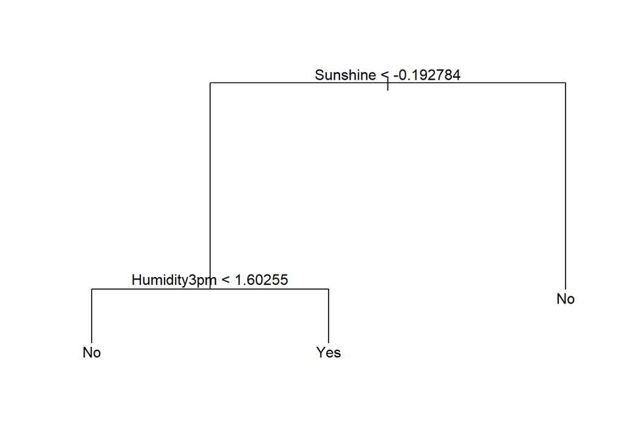

```r
plot(prune.tree)
text(prune.tree)
```

```r
tree_adj_fun2(3)
```

```
## Accuracy      AUC
##   0.8062   0.7216
```

The best tree model uses *Sunshine* and *Humidity3pm* variables. The accuracy is 80.62% and AUC is 72.16%.

```r
# Random Forest model improved process.
set.seed(28652703)
RF_adj_fun <- function(nt, mtry) {
  train_im <- train
  WAUS.RF <- randomForest(RainTomorrow ~ ., data = train, ntree=nt,
                          mtry=mtry)

  RF.pred <- predict(WAUS.RF, test.x)
  RF.cm <- table(observed=test.y, predicted=RF.pred)
  RF.ac <- (RF.cm[1, 1] + RF.cm[2, 2])/sum(RF.cm)

  RF.pred.conf <- predict(WAUS.RF, test.x, type='prob')
  RFpred <- ROCR::prediction(RF.pred.conf[, 2], test.y)
  RFperf <- ROCR::performance(RFpred, 'tpr', 'fpr')
  RF.auc <- ROCR::performance(RFpred, 'auc')@y.values[[1]]

  ret <- c(RF.ac, RF.auc)
  names(ret) <- c('Accuracy', 'AUC')
  return(ret)
}


nt <- seq(50, 1000, by=50)
mtry <- seq(2, 20, by=2)


paras <- expand.grid(nt, mtry)
colnames(paras) <- c('ntree', 'mtry')

RF_adj <- t(apply(paras, 1, function(x) RF_adj_fun(x[1], x[2])))

RF_adj[which.max(RF_adj[, 1]), ]
```

```
## Accuracy      AUC
##   0.8566   0.8431
```

```r
paras[which.max(RF_adj[, 1]), ]
```

```
##    ntree mtry
## 85   250   10
```

```r
RF_adj[which.max(RF_adj[, 2]), ]
```

```
## Accuracy      AUC
##   0.8411   0.8462
```

```r
paras[which.max(RF_adj[, 2]), ]
```

```
##    ntree mtry
## 89   450   10
```

We optimize the randomForest model by adjusting the *ntree* and *mtry* parameters using grid search methods. The highest accuracy we can achieve is 85.66% with *ntree*=250, *mtry*=10. And the highest AUC is 84.62% with *ntree*=450, *mtry*=10.

(I set seed in this part because my randomForest model produces slightly different results whenever I rerun it.)

## 10. Artificial Neural Network classifier

```r
train$RainTomorrow <- ifelse(train$RainTomorrow == 'Yes', 1, 0)
test.y <- ifelse(test.y == 'Yes', 1, 0)

WAUS.net <- neuralnet(RainTomorrow ~ ., data=train[, im.varis3])
net.pred <- round(predict(WAUS.net, test.x[, im.varis3[-6]]), 0)

net.cm <- table(observed=test.y, predicted=net.pred)
net.ac <- (net.cm[1, 1] + net.cm[2, 2])/sum(net.cm)
net.ac
```

```
## [1] 0.8217
```

```r
netpred <- ROCR::prediction(net.pred, test.y)
netperf <- ROCR::performance(netpred, 'tpr', 'fpr')
net.auc <- ROCR::performance(netpred, 'auc')@y.values[[1]]
net.auc
```

```
## [1] 0.6806
```

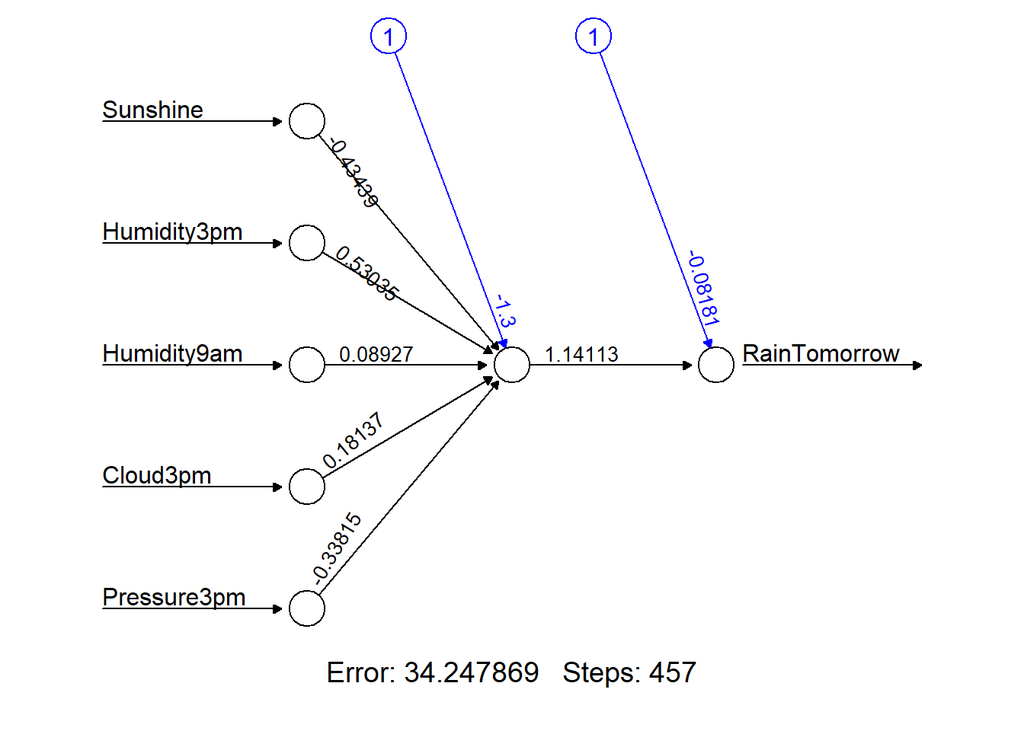

```r
plot(WAUS.net, rep='best')
```

The accuracy of ANN model is 82.17%, but the AUC is 68.06%. The attributes used in ANN model are the important variables from the above model. These include *Sunshine*, *Humidity3pm*, *Humidity9am*, *Cloud3pm* and *Pressure3pm*.

To implement an ANN model, we need to recode the *RainTomorrow* to numerical type as 0 or 1. Here 1 means tomorrow will rain and 0 means tomorrow will not rain.

The ANN model performs same level accuracy, but the AUC is far below the other models. And *Min-Max scaling* methods cannot improve the model any further.

# 11. Report

The main task of this assignment is to predict whether it is going to rain tomorrow in Australia. Finally, We implemented a randomForest model which chose from several models by accuracy and AUC measures.

The dataset is a modified version of raw data, and we randomly sample 2000 rows. Here we omit the dataset sample and import process. And start with the exploratory data analysis.

## 1. Exploratory data analysis

First, we take a close look at the structure of the dataset.

```r
str(WAUS)
```

```
## 'data.frame':    2000 obs. of  25 variables:
##  $ Day          : int  27 31 21 24 1 31 10 23 13 2 ...
##  $ Month        : int  7 8 8 11 1 10 8 7 3 7 ...
##  $ Year         : int  2014 2019 2012 2017 2014 2018 2013 2014 2018 2010 ...
##  $ Location     : int  7 13 40 8 7 8 13 8 40 3 ...
##  $ MinTemp      : num  -0.1 5.7 18.1 17.4 13 15.6 5.7 9.4 20.4 0.2 ...
##  $ MaxTemp      : num  14.2 19.1 24.4 28.8 28.1 27 15.7 22.8 31.8 10.9 ...
##  $ Rainfall     : num  0.2 0 0 1.2 0.2 NA 4.4 2.4 0 0.2 ...
##  $ Evaporation  : num  NA NA 3 8 7 6.8 0.8 3.6 8.4 NA ...
##  $ Sunshine     : num  NA NA 1.3 12.4 NA 9.9 8.1 9.8 NA NA ...
##  $ WindGustDir  : Factor w/ 16 levels "E","ENE","ESE",..: 4 4 3 1 7 6 15 1 5 3 ...
##  $ WindGustSpeed: int  31 59 31 33 59 24 37 20 39 19 ...
##  $ WindDir9am   : Factor w/ 16 levels "E","ENE","ESE",..: NA 4 10 3 11 6 7 13 10 9 ...
##  $ WindDir3pm   : Factor w/ 16 levels "E","ENE","ESE",..: 4 7 3 1 4 5 14 5 2 11 ...
##  $ WindSpeed9am : int  0 20 15 7 20 6 9 7 19 2 ...
##  $ WindSpeed3pm : int  17 22 22 19 11 7 17 6 28 7 ...
##  $ Humidity9am  : int  99 59 74 61 43 59 94 76 54 99 ...
##  $ Humidity3pm  : int  78 50 67 50 31 54 68 54 55 70 ...
##  $ Pressure9am  : num  1027 1020 1020 1017 1010 ...
##  $ Pressure3pm  : num  1022 1016 1016 1014 1006 ...
##  $ Cloud9am     : int  8 NA 8 3 3 6 NA 1 NA 8 ...
##  $ Cloud3pm     : int  7 NA 6 1 4 1 NA 3 NA 4 ...
##  $ Temp9am      : num  3.8 12.3 20.5 24.9 19.6 24.2 8.4 14.5 27.6 3.2 ...
##  $ Temp3pm      : num  13.2 17.8 23.9 27.1 26.6 26.8 15.1 19.8 29.7 10.2 ...
##  $ RainToday    : Factor w/ 2 levels "No","Yes": 1 1 1 2 1 NA 2 2 1 1 ...
##  $ RainTomorrow : Factor w/ 2 levels "No","Yes": 1 2 1 1 2 1 1 1 1 1 ...
```

```r
table(WAUS$RainTomorrow)
```

```
##
##   No  Yes
## 1502  437
```

We omit the whole row which contains *NA* and delete the *Day*, *Month*, and *Year* variables since these variables cannot help to predict *RainTomorrow*.

(Here we noticed that *Rstudio* will not automatically correct the data types if not using the latest version.)

### 1.1 Omit NAs and delete variables

```r
WAUS <- WAUS[!apply(WAUS, 1, anyNA), ]
dim(WAUS)
```

```
## [1] 859  25
```

```r
WAUS <- WAUS[, -c(1:3)]
```

The dataset shrinks from 2000 rows to 859 rows.

### 1.2 Numerical variables

Now we are going to explore the numerical variables.

```r
attach(WAUS)

## for numerical variables
num <- c('MinTemp', 'MaxTemp', 'Rainfall', 'Evaporation', 'Sunshine', 'WindGustSpeed',
         'WindSpeed9am', 'WindSpeed3pm', 'Humidity9am', 'Humidity3pm', 'Pressure9am',
         'Pressure3pm', 'Cloud9am', 'Cloud3pm', 'Temp9am', 'Temp3pm')

fact <- c('WindGustDir', 'WindDir9am', 'WindDir3pm', 'RainToday')



# summary statistics
apply(WAUS[, num], 2, function(x) {
  c(mean=mean(x), median=median(x), sd=sd(x), min=min(x), IQR=IQR(x), max=max(x))
})
```

```
##        MinTemp MaxTemp Rainfall Evaporation Sunshine WindGustSpeed WindSpeed9am
## mean    13.144  23.167    1.796       5.126    7.752         40.07       14.036
## median  12.800  22.900    0.000       4.600    8.800         37.00       13.000
## sd       5.747   6.067    5.401       3.024    3.641         14.56        8.524
## min     -1.400   8.600    0.000       0.000    0.000         11.00        2.000
## IQR      8.800   9.050    0.800       4.500    5.400         18.00       12.000
## max     28.200  41.000   62.800      15.200   13.700        113.00       52.000
##        WindSpeed3pm Humidity9am Humidity3pm Pressure9am Pressure3pm Cloud9am
## mean         19.061       65.27       51.92    1017.714    1015.306    4.168
## median       17.000       65.00       51.00    1018.300    1015.700    5.000
## sd            9.635       15.33       15.96       7.378       7.287    2.757
## min           2.000       18.00        9.00     987.400     986.500    0.000
## IQR          13.000       21.00       20.00       9.150       8.600    6.000
## max          57.000       99.00       98.00    1040.000    1038.500    8.000
##        Cloud3pm Temp9am Temp3pm
## mean      4.208  17.699  21.535
## median    5.000  17.500  21.500
## sd        2.643   6.147   5.885
## min       0.000   2.500   5.800
## IQR       6.000   9.400   8.350
## max       8.000  33.900  37.200
```

The *Rainfall* may contain outliers, we can use boxplot to verify it.

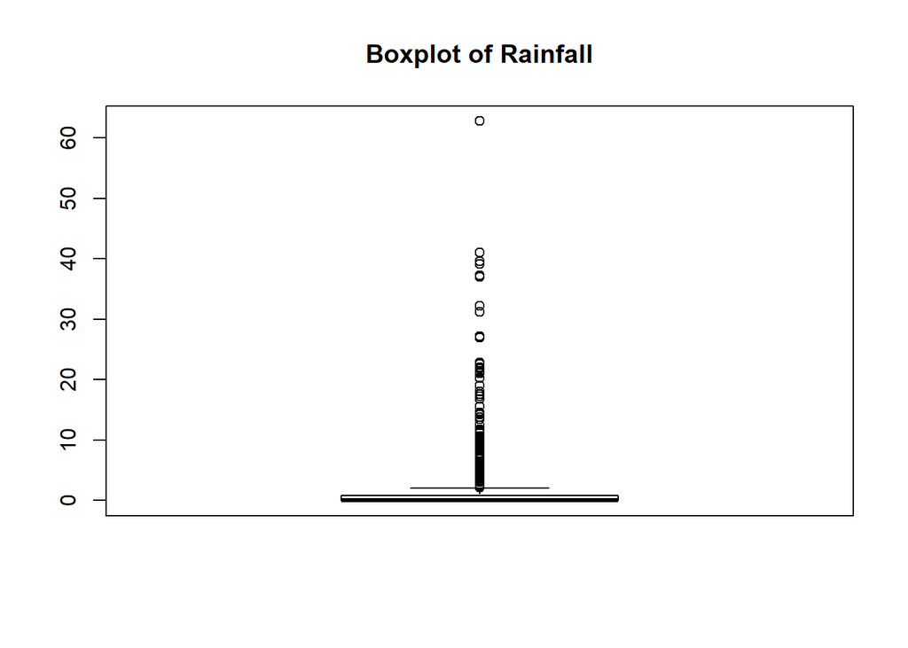

```r
boxplot(Rainfall, main='Boxplot of Rainfall')
```

### 1.3 Categorical variables

```r
## for factor variables

# raintoday and raintomorrow again
table(today=RainToday, tomorrow=RainTomorrow)/length(RainToday)
```

```
##      tomorrow
## today      No     Yes
##   No  0.64377 0.13620
##   Yes 0.13853 0.08149
```

```r
# Wind Gust direction: the proportion of rainy days to fine days
WGD <- table(WindGustDir, RainTomorrow)[, 2]/table(WindGustDir, RainTomorrow)[, 1]

# Wind direction at 9am
WD9 <- table(WindDir9am, RainTomorrow)[, 2]/table(WindDir9am, RainTomorrow)[, 1]

# Wind direction at 3am
WD3 <- table(WindDir3pm, RainTomorrow)[, 2]/table(WindDir3pm, RainTomorrow)[, 1]

data.frame(WGD, WD9, WD3)
```

```
##        WGD    WD9     WD3
## E   0.1000 0.1818 0.26531
## ENE 0.1061 0.1923 0.12162
## ESE 0.4000 0.1667 0.25490
## N   0.4857 0.4667 0.46429
## NE  0.3043 0.5714 0.22034
## NNE 0.2692 0.7895 0.42105
## NNW 0.3462 0.1406 0.76923
## NW  0.4474 0.3725 0.84000
## S   0.4211 0.3548 0.31818
## SE  0.4194 0.3214 0.23077
## SSE 0.2333 0.2647 0.33333
## SSW 0.2131 0.2558 0.29268
## SW  0.1765 0.1806 0.08065
## W   0.2131 0.3409 0.24528
## WNW 0.3939 0.1892 0.35484
## WSW 0.3429 0.2333 0.23684
```

```r
apply(data.frame(WGD, WD9, WD3), 2, mean)
```

```
##    WGD    WD9    WD3
## 0.3045 0.3139 0.3406
```

```r
apply(data.frame(WGD, WD9, WD3), 2, sd)
```

```
##    WGD    WD9    WD3
## 0.1214 0.1735 0.2054
```

We calculate the proportion of rainy days to fine days for different wind gust direction and wind direction at 9am/3pm. And using standard deviation to evaluate the deviation caused by different wind directions. The NNW and NW direction wind at 3pm is more likely to cause rain tomorrow.

## 2. Pre-process

### 2.1 Categorical variables and outliers process

Removing the missing values by omitting the whole row, which was showed in part 1.

Then deal with the *Rainfall* outliers.

```r
toprainfall <- quantile(Rainfall, 0.75) + 3*IQR(Rainfall)

WAUS$Rainfall <- ifelse(WAUS$Rainfall >= toprainfall, toprainfall, WAUS$Rainfall)
```

Categorical variables need to be transformed into indicator variables.

```r
Locat <- createDummyFeatures(data.frame(Locat = as.factor(Location)))

WGD_dum <- createDummyFeatures(data.frame(WGD = as.factor(WindGustDir)))

WD9am_dum <- createDummyFeatures(data.frame(WD9am = as.factor(WindDir9am)))

WD3pm_dum <- createDummyFeatures(data.frame(WD3pm = as.factor(WindDir3pm)))

RT_dum <- createDummyFeatures(data.frame(RT = as.factor(RainToday)))
```

We scale all the numerical variables and bind the new dataset that suitable for the model fitting.

```r
WAUS <- cbind(scale(WAUS[, num]), cbind(Locat,
                                 WGD_dum,
                                 WD9am_dum,
                                 WD3pm_dum,
                                 RT_dum), RainTomorrow=as.factor(RainTomorrow))

# dimension of new dataset
dim(WAUS)
```

```
## [1] 859  74
```

### 2.2 Divide train and test set

We randomly sample 70% as training set and the remaining as testing set.

```r
set.seed(28652703)
train.row <- sample(1:nrow(WAUS), 0.7*nrow(WAUS))

train <- WAUS[train.row, ]

test.x <- WAUS[-train.row, -ncol(WAUS)]
test.y <- WAUS[-train.row, ncol(WAUS)]
```

## 3. Fitting classification models and comparison

First, we try to fit the *tree*, *NaiveBayes*, *Bagging*, *Boosting*, *randomForest* and *ANN* models, then we compare them using appropriate measurements.

### 3.1 Implement the models

```r
WAUS.tree <- tree(RainTomorrow ~ ., data = train)

WAUS.NB <- naiveBayes(RainTomorrow ~ ., data = train)

WAUS.Bagging <- bagging(RainTomorrow ~ ., data = train)

WAUS.Boosting <- boosting(RainTomorrow ~ ., data = train)

WAUS.RF <- randomForest(RainTomorrow ~ ., data = train)
```

### 3.2 Classify, Confusion matrix and Accuracy

```r
# Decision Tree
tree.pred <- predict(WAUS.tree, test.x, type='class')
tree.cm <- table(observed=test.y, predicted=tree.pred)
tree.ac <- (tree.cm[1, 1] + tree.cm[2, 2])/sum(tree.cm)
# confusion matrix
tree.cm
```

```
##         predicted
## observed  No Yes
##      No  168  30
##      Yes  36  24
```

```r
# Naive Bayes
NB.pred <- predict(WAUS.NB, test.x)
NB.cm <- table(observed=test.y, predicted=NB.pred)
NB.ac <- (NB.cm[1, 1] + NB.cm[2, 2])/sum(NB.cm)
# confusion matrix
NB.cm
```

```
##         predicted
## observed  No Yes
##      No  136  62
##      Yes  24  36
```

```r
# Bagging
Bagging.pred <- predict(WAUS.Bagging, test.x)
Bagging.cm <- table(observed=test.y, predicted=Bagging.pred$class)
Bagging.ac <- (Bagging.cm[1, 1] + Bagging.cm[2, 2])/sum(Bagging.cm)
# confusion matrix
Bagging.cm
```

```
##         predicted
## observed  No Yes
##      No  192   6
##      Yes  34  26
```

```r
# Boosting
Boosting.pred <- predict(WAUS.Boosting, test.x)
Boosting.cm <- table(observed=test.y, predicted=Boosting.pred$class)
Boosting.ac <- (Boosting.cm[1, 1] + Boosting.cm[2, 2])/sum(Boosting.cm)
# confusion matrix
Boosting.cm
```

```
##         predicted
## observed  No Yes
##      No  183  15
##      Yes  34  26
```

```r
# randomForest
RF.pred <- predict(WAUS.RF, test.x)
RF.cm <- table(observed=test.y, predicted=RF.pred)
RF.ac <- (RF.cm[1, 1] + RF.cm[2, 2])/sum(RF.cm)
# confusion matrix
RF.cm
```

```
##         predicted
## observed  No Yes
##      No  192   6
##      Yes  36  24
```

```r
# Report the accuracy of each model.
ac <- data.frame(ModelName = c('tree', 'NaiveBayes', 'Bagging',
                               'Boosting', 'randomForest'),
                 Accuracy = c(tree.ac, NB.ac, Bagging.ac,
                              Boosting.ac, RF.ac))
ac
```

```
##      ModelName Accuracy
## 1         tree   0.7442
## 2   NaiveBayes   0.6667
## 3      Bagging   0.8450
## 4     Boosting   0.8101
## 5 randomForest   0.8372
```

From the accuracy table above, we can see that Bagging model has the highest accuracy (84.5%), then randomFroest model, NaiveBayes is the lowest with only 66.67%.

### 3.3 Confidence, ROC and AUC

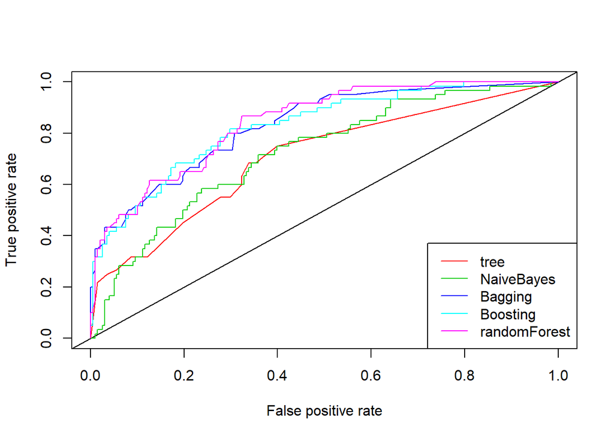

```r
# confidence of predicting
tree.pred.conf <- predict(WAUS.tree, test.x, type='vector')
treepred <- ROCR::prediction(tree.pred.conf[, 2], test.y)
treeperf <- ROCR::performance(treepred, 'tpr', 'fpr')
tree.auc <- ROCR::performance(treepred, 'auc')@y.values[[1]]


NB.pred.conf <- predict(WAUS.NB, test.x, type='raw')
NBpred <- ROCR::prediction(NB.pred.conf[, 2], test.y)
NBperf <- ROCR::performance(NBpred, 'tpr', 'fpr')
NB.auc <- ROCR::performance(NBpred, 'auc')@y.values[[1]]


Baggingpred <- ROCR::prediction(Bagging.pred$prob[, 2], test.y)
Baggingperf <- ROCR::performance(Baggingpred, 'tpr', 'fpr')
Bagging.auc <- ROCR::performance(Baggingpred, 'auc')@y.values[[1]]


Boostingpred <- ROCR::prediction(Boosting.pred$prob[, 2], test.y)
Boostingperf <- ROCR::performance(Boostingpred, 'tpr', 'fpr')
Boosting.auc <- ROCR::performance(Boostingpred, 'auc')@y.values[[1]]


RF.pred.conf <- predict(WAUS.RF, test.x, type='prob')
RFpred <- ROCR::prediction(RF.pred.conf[, 2], test.y)
RFperf <- ROCR::performance(RFpred, 'tpr', 'fpr')
RF.auc <- ROCR::performance(RFpred, 'auc')@y.values[[1]]


# ROC plot
plot(treeperf, col=2)
abline(0, 1)
plot(NBperf, col=3, add=TRUE)
plot(Baggingperf, col=4, add=TRUE)
plot(Boostingperf, col=5, add=TRUE)
plot(RFperf, col=6, add=TRUE)
legend('bottomright', legend=c('tree', 'NaiveBayes',
                               'Bagging', 'Boosting', 'randomForest'),
       col=c(2:6), lty=1)
```

```r
# AUC
auc <- data.frame(ModelName = c('tree', 'NaiveBayes', 'Bagging',
                               'Boosting', 'randomForest'),
                  Auc = c(tree.auc, NB.auc, Bagging.auc,
                          Boosting.auc, RF.auc))
auc
```

```
##      ModelName    Auc
## 1         tree 0.7056
## 2   NaiveBayes 0.7235
## 3      Bagging 0.8295
## 4     Boosting 0.8275
## 5 randomForest 0.8433
```

From the ROC curve, we can see that Bagging, Boosting and randomForest perform better than tree and NaiveBayes model. The randomFroest model has the highest AUC while the tree model is lowest.

```r
merge(ac,auc)
```

```
##      ModelName Accuracy    Auc
## 1      Bagging   0.8450 0.8295
## 2     Boosting   0.8101 0.8275
## 3   NaiveBayes   0.6667 0.7235
## 4 randomForest   0.8372 0.8433
## 5         tree   0.7442 0.7056
```

Combining the accuracy and AUC into one table, Bagging and randomForest perform best among these models.

randomForest seems to be the ‘best’ classifier.

### 3.4 Important variables

In order to adjust models, we have to discover important variables.

```r
# Attribute importance
cat("\n#Decision Tree Attribute Importance\n")
```

```
##
## #Decision Tree Attribute Importance
```

```r
print(summary(WAUS.tree))
```

```
##
## Classification tree:
## tree(formula = RainTomorrow ~ ., data = train)
## Variables actually used in tree construction:
##  [1] "Sunshine"      "Humidity3pm"   "Humidity9am"   "WGD.NW"
##  [5] "Rainfall"      "WGD.ESE"       "WindGustSpeed" "Temp9am"
##  [9] "MaxTemp"       "Temp3pm"       "Cloud3pm"      "WindSpeed9am"
## [13] "Cloud9am"      "Evaporation"   "Pressure9am"   "WD3pm.NNW"
## [17] "WD3pm.NW"      "WD3pm.E"       "Locat.8"
## Number of terminal nodes:  29
## Residual mean deviance:  0.386 = 221 / 572
## Misclassification error rate: 0.101 = 61 / 601
```

```r
tree.im <- as.character(summary(WAUS.tree)[['used']])

cat("\n#Bagging Attribute Importance\n")
```

```
##
## #Bagging Attribute Importance
```

```r
print(WAUS.Bagging$importance)
```

```
##      Cloud3pm      Cloud9am   Evaporation   Humidity3pm   Humidity9am
##       1.52053       0.85677       3.29661      26.30190       4.62948
##      Locat.16      Locat.19      Locat.32      Locat.36      Locat.39
##       0.36773       1.45628       0.38232       0.00000       0.02646
##      Locat.40       Locat.8       MaxTemp       MinTemp   Pressure3pm
##       0.12669       0.48125       0.82643       1.37017       4.50320
##   Pressure9am      Rainfall         RT.No        RT.Yes      Sunshine
##       4.00949       3.09100       0.00000       0.00000      30.34759
##       Temp3pm       Temp9am       WD3pm.E     WD3pm.ENE     WD3pm.ESE
##       0.95019       1.42721       0.04221       0.00000       0.20290
##       WD3pm.N      WD3pm.NE     WD3pm.NNE     WD3pm.NNW      WD3pm.NW
##       0.04438       0.00000       0.00000       0.26457       0.34879
##       WD3pm.S      WD3pm.SE     WD3pm.SSE     WD3pm.SSW      WD3pm.SW
##       0.00000       0.04835       0.07221       0.10977       0.17303
##       WD3pm.W     WD3pm.WNW     WD3pm.WSW       WD9am.E     WD9am.ENE
##       0.05996       0.00000       0.00000       0.06193       0.00000
##     WD9am.ESE       WD9am.N      WD9am.NE     WD9am.NNE     WD9am.NNW
##       0.00000       0.22117       0.15797       0.24355       0.12117
##      WD9am.NW       WD9am.S      WD9am.SE     WD9am.SSE     WD9am.SSW
##       0.05003       0.03129       0.00000       0.00000       0.00000
##      WD9am.SW       WD9am.W     WD9am.WNW     WD9am.WSW         WGD.E
##       0.11077       0.13011       0.00000       0.02026       0.00000
##       WGD.ENE       WGD.ESE         WGD.N        WGD.NE       WGD.NNE
##       0.00000       0.88475       0.07201       0.10070       0.00000
##       WGD.NNW        WGD.NW         WGD.S        WGD.SE       WGD.SSE
##       0.45106       1.16815       0.12429       0.00000       0.09359
##       WGD.SSW        WGD.SW         WGD.W       WGD.WNW       WGD.WSW
##       0.21780       0.00000       0.00000       0.05355       0.00000
## WindGustSpeed  WindSpeed3pm  WindSpeed9am
##       3.83901       1.67701       2.83236
```

```r
Bagging.im <- sort(WAUS.Bagging$importance[WAUS.Bagging$importance != 0], decreasing = T)

cat("\n#Boosting Attribute Importance\n")
```

```
##
## #Boosting Attribute Importance
```

```r
print(WAUS.Boosting$importance)
```

```
##      Cloud3pm      Cloud9am   Evaporation   Humidity3pm   Humidity9am
##       2.86661       3.52305       6.61609       7.20760       4.94249
##      Locat.16      Locat.19      Locat.32      Locat.36      Locat.39
##       0.62787       0.97533       0.65461       0.18064       0.15243
##      Locat.40       Locat.8       MaxTemp       MinTemp   Pressure3pm
##       0.29405       0.88229       5.13464       5.78041       6.34405
##   Pressure9am      Rainfall         RT.No        RT.Yes      Sunshine
##       6.84276       3.10576       0.00000       0.00000       8.22516
##       Temp3pm       Temp9am       WD3pm.E     WD3pm.ENE     WD3pm.ESE
##       4.18291       3.00281       0.32588       0.08646       0.28769
##       WD3pm.N      WD3pm.NE     WD3pm.NNE     WD3pm.NNW      WD3pm.NW
##       0.14231       0.22307       0.11595       0.73421       0.85509
##       WD3pm.S      WD3pm.SE     WD3pm.SSE     WD3pm.SSW      WD3pm.SW
##       0.27745       0.10053       0.09200       0.28601       0.89265
##       WD3pm.W     WD3pm.WNW     WD3pm.WSW       WD9am.E     WD9am.ENE
##       0.06468       0.09709       0.10660       0.11774       0.10411
##     WD9am.ESE       WD9am.N      WD9am.NE     WD9am.NNE     WD9am.NNW
##       0.20715       0.18163       0.50169       0.09184       0.99780
##      WD9am.NW       WD9am.S      WD9am.SE     WD9am.SSE     WD9am.SSW
##       0.41698       0.11103       0.44950       0.07623       0.11283
##      WD9am.SW       WD9am.W     WD9am.WNW     WD9am.WSW         WGD.E
##       0.27681       0.38782       0.18978       0.23005       0.42736
##       WGD.ENE       WGD.ESE         WGD.N        WGD.NE       WGD.NNE
##       0.36011       0.64869       0.14566       0.12820       0.18926
##       WGD.NNW        WGD.NW         WGD.S        WGD.SE       WGD.SSE
##       0.41510       0.25008       0.36102       0.43887       0.23884
##       WGD.SSW        WGD.SW         WGD.W       WGD.WNW       WGD.WSW
##       0.98552       0.11892       0.22029       0.08750       0.00000
## WindGustSpeed  WindSpeed3pm  WindSpeed9am
##       6.20964       4.32618       3.76653
```

```r
Boosting.im <- sort(WAUS.Boosting$importance[WAUS.Boosting$importance != 0], decreasing = T)

cat("\n#Random Forest Attribute Importance\n")
```

```
##
## #Random Forest Attribute Importance
```

```r
print(WAUS.RF$importance)
```

```
##               MeanDecreaseGini
## MinTemp                 6.9571
## MaxTemp                 7.6852
## Rainfall                5.4883
## Evaporation             7.1685
## Sunshine               19.5874
## WindGustSpeed           8.5425
## WindSpeed9am            5.7325
## WindSpeed3pm            6.2883
## Humidity9am            11.5768
## Humidity3pm            22.0948
## Pressure9am             9.4299
## Pressure3pm            10.2544
## Cloud9am                8.1360
## Cloud3pm               11.1470
## Temp9am                 6.8878
## Temp3pm                 7.6036
## Locat.8                 1.0236
## Locat.16                0.9948
## Locat.19                1.3822
## Locat.32                1.3833
## Locat.36                0.4160
## Locat.39                0.8119
## Locat.40                0.4481
## WGD.E                   0.5646
## WGD.ENE                 0.4101
## WGD.ESE                 1.2844
## WGD.N                   0.6549
## WGD.NE                  0.3963
## WGD.NNE                 0.4199
## WGD.NNW                 1.0529
## WGD.NW                  1.2049
## WGD.S                   0.6720
## WGD.SE                  0.8381
## WGD.SSE                 0.5858
## WGD.SSW                 0.7788
## WGD.SW                  0.6484
## WGD.W                   0.5784
## WGD.WNW                 0.6102
## WGD.WSW                 0.4097
```

[output cut: 19 more lines]

```
## WD3pm.N                 0.4324
## WD3pm.NE                0.4335
## WD3pm.NNE               0.4263
## WD3pm.NNW               1.5221
## WD3pm.NW                1.7918
## WD3pm.S                 0.5702
## WD3pm.SE                0.5645
## WD3pm.SSE               0.5579
## WD3pm.SSW               0.4915
## WD3pm.SW                0.7228
## WD3pm.W                 0.5706
## WD3pm.WNW               0.7000
## WD3pm.WSW               0.3664
## RT.No                   1.9751
## RT.Yes                  1.9519
```

```r
RF.im <- sort(WAUS.RF$importance[WAUS.RF$importance != 0, ], decreasing = T)


im.list <- list(tree=tree.im, Bagging=Bagging.im, Boosting=Boosting.im,
                RF=RF.im)
im.list
```

```
## $tree
##  [1] "Sunshine"      "Humidity3pm"   "Humidity9am"   "WGD.NW"
##  [5] "Rainfall"      "WGD.ESE"       "WindGustSpeed" "Temp9am"
##  [9] "MaxTemp"       "Temp3pm"       "Cloud3pm"      "WindSpeed9am"
## [13] "Cloud9am"      "Evaporation"   "Pressure9am"   "WD3pm.NNW"
## [17] "WD3pm.NW"      "WD3pm.E"       "Locat.8"
##
## $Bagging
##      Sunshine   Humidity3pm   Humidity9am   Pressure3pm   Pressure9am
##      30.34759      26.30190       4.62948       4.50320       4.00949
## WindGustSpeed   Evaporation      Rainfall  WindSpeed9am  WindSpeed3pm
##       3.83901       3.29661       3.09100       2.83236       1.67701
##      Cloud3pm      Locat.19       Temp9am       MinTemp        WGD.NW
##       1.52053       1.45628       1.42721       1.37017       1.16815
##       Temp3pm       WGD.ESE      Cloud9am       MaxTemp       Locat.8
##       0.95019       0.88475       0.85677       0.82643       0.48125
##       WGD.NNW      Locat.32      Locat.16      WD3pm.NW     WD3pm.NNW
##       0.45106       0.38232       0.36773       0.34879       0.26457
##     WD9am.NNE       WD9am.N       WGD.SSW     WD3pm.ESE      WD3pm.SW
##       0.24355       0.22117       0.21780       0.20290       0.17303
##      WD9am.NE       WD9am.W      Locat.40         WGD.S     WD9am.NNW
##       0.15797       0.13011       0.12669       0.12429       0.12117
##      WD9am.SW     WD3pm.SSW        WGD.NE       WGD.SSE     WD3pm.SSE
##       0.11077       0.10977       0.10070       0.09359       0.07221
##         WGD.N       WD9am.E       WD3pm.W       WGD.WNW      WD9am.NW
##       0.07201       0.06193       0.05996       0.05355       0.05003
##      WD3pm.SE       WD3pm.N       WD3pm.E       WD9am.S      Locat.39
##       0.04835       0.04438       0.04221       0.03129       0.02646
##     WD9am.WSW
##       0.02026
##
## $Boosting
##      Sunshine   Humidity3pm   Pressure9am   Evaporation   Pressure3pm
##       8.22516       7.20760       6.84276       6.61609       6.34405
## WindGustSpeed       MinTemp       MaxTemp   Humidity9am  WindSpeed3pm
##       6.20964       5.78041       5.13464       4.94249       4.32618
##       Temp3pm  WindSpeed9am      Cloud9am      Rainfall       Temp9am
##       4.18291       3.76653       3.52305       3.10576       3.00281
##      Cloud3pm     WD9am.NNW       WGD.SSW      Locat.19      WD3pm.SW
##       2.86661       0.99780       0.98552       0.97533       0.89265
```

[output cut: 37 more lines]

```
##        0.7788        0.7748        0.7228        0.7000        0.6977
##     WD9am.WSW       WD9am.W         WGD.S         WGD.N        WGD.SW
##        0.6854        0.6841        0.6720        0.6549        0.6484
##     WD3pm.ESE       WD9am.S       WGD.WNW       WGD.SSE         WGD.W
##        0.6215        0.6128        0.6102        0.5858        0.5784
##       WD3pm.W       WD3pm.S         WGD.E      WD3pm.SE      WD9am.SE
##        0.5706        0.5702        0.5646        0.5645        0.5586
##     WD3pm.SSE     WD9am.SSE     WD9am.ESE     WD3pm.SSW     WD3pm.ENE
##        0.5579        0.5178        0.5143        0.4915        0.4538
##       WD9am.E      Locat.40      WD3pm.NE       WD3pm.N     WD3pm.NNE
##        0.4498        0.4481        0.4335        0.4324        0.4263
##       WGD.NNE      Locat.36       WGD.ENE       WGD.WSW        WGD.NE
##        0.4199        0.4160        0.4101        0.4097        0.3963
##     WD3pm.WSW     WD9am.WNW     WD9am.ENE
##        0.3664        0.3191        0.2413
```

Important variables are *Sunshine*, *Humidity*, *Pressure*, etc. Because these variables bring higher contribution to model accuracy and information gains. However, *RainToday*, *Location* and *Wind Direction* seem to be less significant in most of our models.

Then we set three levels of important variables from the above results.

```r
im.varis <- c('Sunshine', 'Humidity3pm', 'Humidity9am', 'Cloud3pm',
              'Pressure3pm', 'Pressure9am', 'WindGustSpeed', 'Evaporation',
              'RainTomorrow')

im.varis2 <- c('Sunshine', 'Humidity3pm', 'Humidity9am', 'Cloud3pm',
              'Pressure3pm', 'Pressure9am','RainTomorrow')

im.varis3 <- c('Sunshine', 'Humidity3pm', 'Humidity9am', 'Cloud3pm',
              'Pressure3pm', 'RainTomorrow')
```

## 4. Improving tree models

### 4.1 Cross validation and prune trees

First, we try different important attributes with the tree model. Then prune the trees by cross validation.

```r
# Tree model improved process
train_im <- train
tree_adj_fun <- function(im) {

  train_im <- train[, im]
  WAUS.tree <- tree(RainTomorrow ~ ., data = train_im)

  tree.pred <- predict(WAUS.tree, test.x, type='class')
  tree.cm <- table(observed=test.y, predicted=tree.pred)
  tree.ac <- (tree.cm[1, 1] + tree.cm[2, 2])/sum(tree.cm)

  tree.pred.conf <- predict(WAUS.tree, test.x, type='vector')
  treepred <- ROCR::prediction(tree.pred.conf[, 2], test.y)
  treeperf <- ROCR::performance(treepred, 'tpr', 'fpr')
  tree.auc <- ROCR::performance(treepred, 'auc')@y.values[[1]]

  ret1 <- c(tree.ac, tree.auc)

  # prune tree
  testtree <- cv.tree(WAUS.tree, FUN=prune.misclass)
  size <- testtree$size[which.min(testtree$dev)]

  prune.tree <- prune.misclass(WAUS.tree, best=size)
  prune.tree.pred <- predict(prune.tree, test.x, type='class')

  prune.tree.cm <- table(observed=test.y, predicted=prune.tree.pred)
  prune.tree.ac <- (prune.tree.cm[1, 1] + prune.tree.cm[2, 2])/sum(prune.tree.cm)
  prune.tree.ac

  prune.tree.pred.conf <- predict(prune.tree, test.x, type='vector')
  prune.treepred <- ROCR::prediction(prune.tree.pred.conf[, 2], test.y)
  prune.treeperf <- ROCR::performance(prune.treepred, 'tpr', 'fpr')
  prune.tree.auc <- ROCR::performance(prune.treepred, 'auc')@y.values[[1]]
  prune.tree.auc

  ret2 <- c(prune.tree.ac, prune.tree.auc)

  ret <- rbind(ret1, ret2)
  colnames(ret) <- c('Accuracy', 'AUC')
  rownames(ret) <- c('Raw', 'Pruned')

  return(ret)
}


## the all variables
tree_adj_fun(colnames(train))
```

```
##        Accuracy    AUC
## Raw      0.7403 0.7056
## Pruned   0.8062 0.7216
```

```r
## the first level important variables
tree_adj_fun(im.varis)
```

```
##        Accuracy    AUC
## Raw      0.7713 0.7154
## Pruned   0.8062 0.7216
```

```r
## the second level important variables
tree_adj_fun(im.varis2)
```

```
##        Accuracy    AUC
## Raw      0.7946 0.7572
## Pruned   0.8062 0.7216
```

```r
## the third level important variables
tree_adj_fun(im.varis3)
```

```
##        Accuracy   AUC
## Raw      0.7984 0.765
## Pruned   0.7984 0.718
```

The third level important variables perform the best. On the other hand, we use all variables but optimize the best number of terminal nodes.

```r
train_im <- train

tree_adj_fun2 <- function(size1) {
  train_im <- train
  WAUS.tree <- tree(RainTomorrow ~ ., data = train_im)

  prune.tree <- prune.misclass(WAUS.tree, best=size1)
  prune.tree.pred <- predict(prune.tree, test.x, type='class')

  prune.tree.cm <- table(observed=test.y, predicted=prune.tree.pred)
  prune.tree.ac <- (prune.tree.cm[1, 1] + prune.tree.cm[2, 2])/sum(prune.tree.cm)
  prune.tree.ac

  prune.tree.pred.conf <- predict(prune.tree, test.x, type='vector')
  prune.treepred <- ROCR::prediction(prune.tree.pred.conf[, 2], test.y)
  prune.treeperf <- ROCR::performance(prune.treepred, 'tpr', 'fpr')
  prune.tree.auc <- ROCR::performance(prune.treepred, 'auc')@y.values[[1]]
  prune.tree.auc

  ret2 <- c(prune.tree.ac, prune.tree.auc)

  names(ret2) <- c('Accuracy', 'AUC')

  return(ret2)
}

t(sapply(c(2:15), tree_adj_fun2))
```

```
##       Accuracy    AUC
##  [1,]   0.8062 0.7216
##  [2,]   0.8062 0.7216
##  [3,]   0.7984 0.7180
##  [4,]   0.7868 0.7176
##  [5,]   0.7791 0.7107
##  [6,]   0.7442 0.6298
##  [7,]   0.7558 0.6298
##  [8,]   0.7326 0.6298
##  [9,]   0.7326 0.6298
## [10,]   0.7364 0.6298
## [11,]   0.7248 0.6298
## [12,]   0.7558 0.6298
## [13,]   0.7597 0.6298
## [14,]   0.7442 0.6298
```

### 4.2 C50 tree model

Now we will try to fit C50 tree based algorithm.

```r
# try C50 tree based algorithm
WAUS.C50.1 <- C5.0(train[, -74], y = train$RainTomorrow)
table(predict(WAUS.C50.1, test.x), test.y)
```

```
##      test.y
##        No Yes
##   No  169  34
##   Yes  29  26
```

```r
WAUS.C50.2 <- C5.0(train[, im.varis3[-6]], y = train$RainTomorrow)
table(predict(WAUS.C50.2, test.x), test.y)
```

```
##      test.y
##        No Yes
##   No  191  46
##   Yes   7  14
```

The performance of C5.0 tree based algorithm is not as good as the tree model by *tree* function.

By pruning and choosing the important variables, the best decision tree model is shown below.

### 4.3 The best decision tree model

```r
prune.tree <- prune.misclass(WAUS.tree, best=3)
summary(prune.tree)
```

```
##
## Classification tree:
## snip.tree(tree = WAUS.tree, nodes = c(3L, 5L, 4L))
## Variables actually used in tree construction:
## [1] "Sunshine"    "Humidity3pm"
## Number of terminal nodes:  3
## Residual mean deviance:  0.779 = 466 / 598
## Misclassification error rate: 0.165 = 99 / 601
```

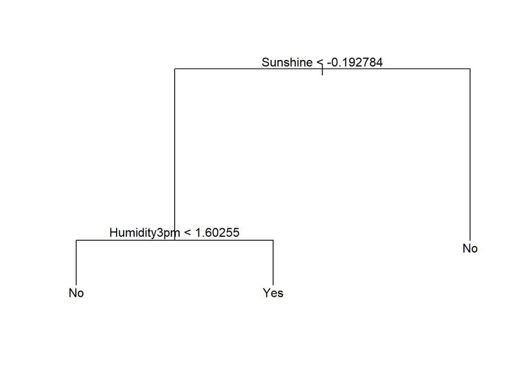

```r
plot(prune.tree)
text(prune.tree)
```

```r
tree_adj_fun2(3)
```

```
## Accuracy      AUC
##   0.8062   0.7216
```

The best decision tree model uses *Sunshine* and *Humidity3pm* variables.

The accuracy is 80.62% and AUC is 72.16%.

### 5. Improving Random Forest model

Now, we will optimize another tree based model (randomForest) by performing grid search on parameters.

```r
# randomForest model improved process.
set.seed(28652703)
RF_adj_fun <- function(nt, mtry) {
  train_im <- train
  WAUS.RF <- randomForest(RainTomorrow ~ ., data = train, ntree=nt,
                          mtry=mtry)

  RF.pred <- predict(WAUS.RF, test.x)
  RF.cm <- table(observed=test.y, predicted=RF.pred)
  RF.ac <- (RF.cm[1, 1] + RF.cm[2, 2])/sum(RF.cm)

  RF.pred.conf <- predict(WAUS.RF, test.x, type='prob')
  RFpred <- ROCR::prediction(RF.pred.conf[, 2], test.y)
  RFperf <- ROCR::performance(RFpred, 'tpr', 'fpr')
  RF.auc <- ROCR::performance(RFpred, 'auc')@y.values[[1]]

  ret <- c(RF.ac, RF.auc)
  names(ret) <- c('Accuracy', 'AUC')
  return(ret)
}


nt <- seq(50, 1000, by=50)
mtry <- seq(2, 20, by=2)

## parameters combination
paras <- expand.grid(nt, mtry)
colnames(paras) <- c('ntree', 'mtry')

## calculate the results for 200 parameters combination
RF_adj <- t(apply(paras, 1, function(x) RF_adj_fun(x[1], x[2])))

## the best accuracy's and its parameter
RF_adj[which.max(RF_adj[, 1]), ]
```

```
## Accuracy      AUC
##   0.8566   0.8431
```

```r
paras[which.max(RF_adj[, 1]), ]
```

```
##    ntree mtry
## 85   250   10
```

```r
RF_adj[which.max(RF_adj[, 2]), ]
```

```
## Accuracy      AUC
##   0.8411   0.8462
```

```r
paras[which.max(RF_adj[, 2]), ]
```

```
##    ntree mtry
## 89   450   10
```

We optimize the randomForest model by adjusting the *ntree* and *mtry* parameters using grid search methods. The highest accuracy we achieved is 85.66% with *ntree*=250, *mtry*=10. The highest AUC is 84.62% with *ntree*=450, *mtry*=10. Adapting the important variables cannot change the results.

(I set seed in this part because my randomForest model produces slightly different results whenever I rerun it.)

Our best tree-based classifier is the improved random forest model shown above.

## 6. ANN model

Based on the above information, we can implement the ANN models.

```r
train$RainTomorrow <- ifelse(train$RainTomorrow == 'Yes', 1, 0)
test.y <- ifelse(test.y == 'Yes', 1, 0)

WAUS.net <- neuralnet(RainTomorrow ~ ., data=train[, im.varis3])
net.pred <- round(predict(WAUS.net, test.x[, im.varis3[-6]]), 0)

net.cm <- table(observed=test.y, predicted=net.pred)
net.ac <- (net.cm[1, 1] + net.cm[2, 2])/sum(net.cm)
net.ac
```

```
## [1] 0.8217
```

```r
netpred <- ROCR::prediction(net.pred, test.y)
netperf <- ROCR::performance(netpred, 'tpr', 'fpr')
net.auc <- ROCR::performance(netpred, 'auc')@y.values[[1]]
net.auc
```

```
## [1] 0.6806
```

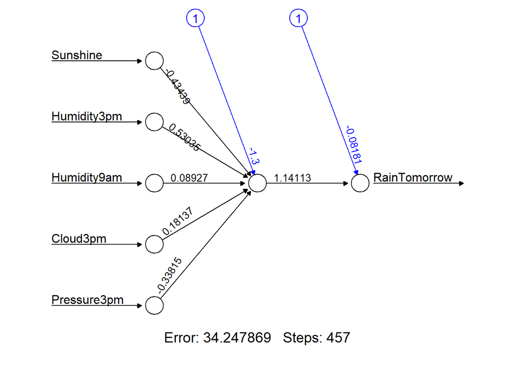

```r
plot(WAUS.net, rep='best')
```

The accuracy of ANN model is 82.17%, but the AUC is 68.06%. The attributes used in ANN model are the important variables from the above model. These include *Sunshine*, *Humidity3pm*, *Humidity9am*, *Cloud3pm* and *Pressure3pm*.

To implement an ANN model, we need to recode the *RainTomorrow* to numerical type as 0 or 1. Here 1 means tomorrow will rain and 0 means tomorrow will not rain.

The ANN model performs same level accuracy but the AUC is far below the other models. And *Min-Max scaling* methods cannot improve the model any further.

Artificial Neural Network is equivalent to a black box, which means that we do not know what kind of results it will produce and why it produces such results.

## 7. Conclusion

By comparing accuracy and AUC of tree, Bagging, Boosting, NaiveBayes, randomForest and ANN models. We found out several important variables such as *Sunshine*,*Humidity*,*Pressure* and *Cloud*. These important variables can help us making an approximate decision for whether tomorrow will rain in our daily lives.

In terms of models, we recommend the randomForest model with the highest AUC parameters (ntree=450, mtry=10). The AUC of randomForest in such randomly sampled dataset is 84.62%.